# US Unemployment Rate and Recession

This project analyzes how the unemployment rate related to the economic recession.

### Data Source

The data is downloaded from [U.S. Bureau of Labor Statistics](https://data.bls.gov/pdq/SurveyOutputServlet). One csv file contains the unemployment rate from 1948 to 2019; another csv file contains the economic recession names and length in the period from 1948 to 2019.

### Set Up Working Environment

Load packages and set up working folders.

### Load Data into R Studio

Load two csv files into dataframes in R Studio.

### Check Data

Check data to ensure the data is clean and validate.

1. Check the structure of data.
2. Check the rows and columns of data.
3. Identify whether there are Null value in the data; if there is any, see whether that need to be fixed.
4. Explore data to Understand context of the data.

### Manipulate Data

Change data format to ensure my data is in a tidy data format.

1. Convert the unemployment rate dateframe to long format so that analysis can be processed by month instead of year.
2. Join the unemployment data and recession data to see the relationship between the unemployment rate and recession.

[1] TRUE [1] TRUE

3. Add the start year_month and end year_month for each recession period. The purpose is to plot the recession period to better communicate the analysis result with stakeholders.

### Analysis

From the data frames we get, we can see the following:

1. How unemployment rate changes from the year of 1948 to the year of 2019.
2. The recession period during between 1948 and 2019.
3. Combine 1. and 2. we can see the relationship between the unemployment rate and the economic recession.

### Visualization

To show the analysis results in a descriptive way, we use ggplot2 to draw the following plots.

1. Unemployment rate change by year_month during the period from 1948 to 2019.

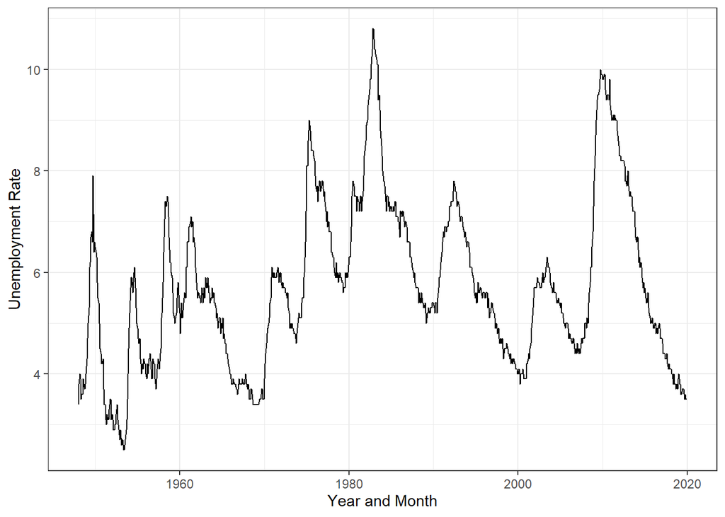

2. Recession mapping during the period from 1948 to 2019.

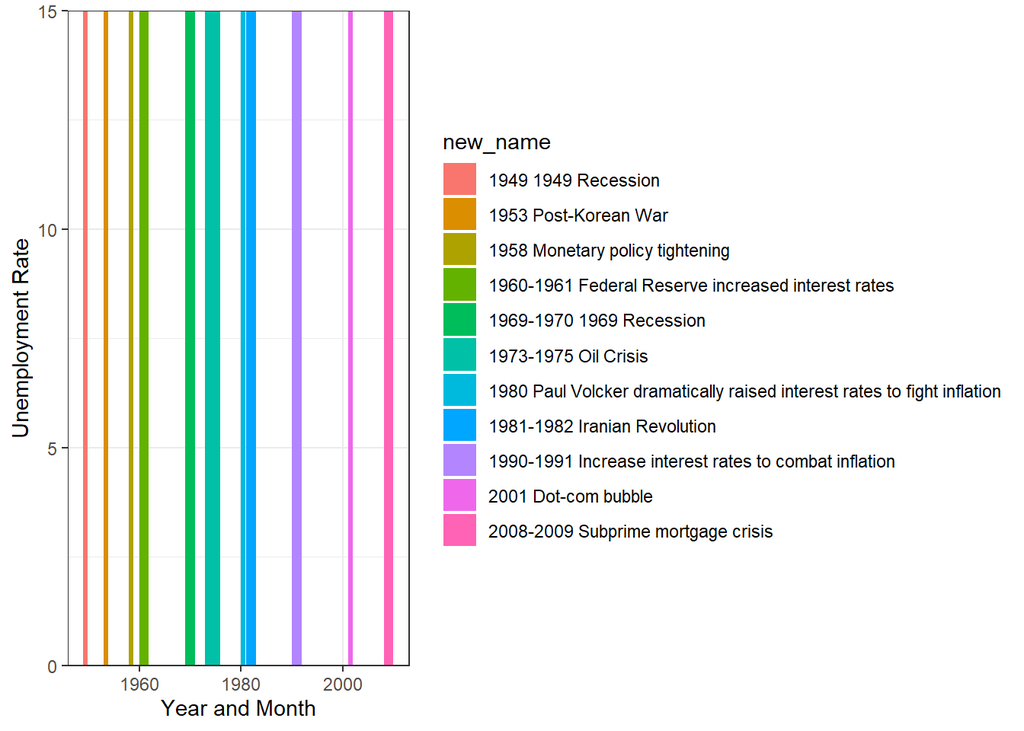

3. The relationship between the unemployment rate and recession during the period from 1948 to 2019.

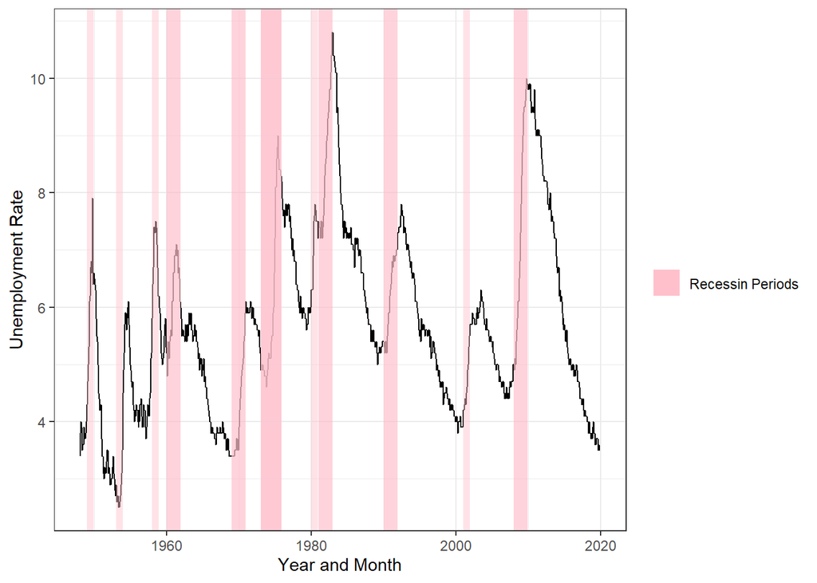

### Conclusion

The unemployment rate is closely related to the economic rescission.

From the plot, we can see that during the period of economic recession, the unemployment rate will go up sharply.

That is because during economic recession, companies couldn’t make good profit. Due to the lack of money, they would need to stop some projects, shrink their production scales and cut of on the cost of human power, so that they could manage to survive the recession period. So more people would get laid off, becoming unemployed.

When economy starts recovering, companies would need to expend production and need more employees; so the unemployment rate would going down.

To decease the unemployment rate, government needs to stimulate the economy. When the economic situation gets better, more human power is demanded on the employment market; and the unemployment rate will go down.